# T-cell repertoire antigen-specificity annotation

Maria S. Benítez-Cantos, Carlos Cano, Armando Blanco

04-07-2020

# 1 Preface

Currently, there are some databases of annotated TCR sequences, with information about its antigen specificity. Some of the available databases are:

- [VDJdb](https://vdjdb.cdr3.net): it can be downloaded and then processed with `immunarch` package.
- [McPAS-TCR](http://friedmanlab.weizmann.ac.il/McPAS-TCR/): it can be downloaded and then processed with `immunarch` package.
- [TBAdb](https://db.cngb.org/pird/tbadb/): it can be downloaded and then processed with `immunarch` package.
- [TCRdb](http://bioinfo.life.hust.edu.cn/TCRdb/#/) (2021): it is a database of TCR-seq projects associated with diseases or conditions, but without antigen specificity annotation.
- [immuneACCESS](https://clients.adaptivebiotech.com/immuneaccess): immuneACCESS is a collection of open-access immunoSEQ projects, often associated with journal articles. These projects are interactive data sets that can be explored. It is not an annotated TCR database and it can not be downloaded in its entirety.

# 2 Aims

1. To annotate our TCR sequences with the databases mentioned above. *Currently, I'm only working with **VDJdb**. The next step is to keep annotating with other databases.*
2. To analyze CMV epitope specificity in blood vs tissues.
3. To identify which self-antigens are being recognized in our samples.

# 3 Results

#### Note!

This is an exploratory analysis. No statistical tests have been carried out to make generalized assumptions about these data.

```
## Number of samples: 32
```

```
## Unique clonotypes among all samples (defined by V name, J name and CDR3 aminoacid sequence): 62937
```

## 3.1 Antigen specificity annotation with VDJdb

[VDJdb](https://vdjdb.cdr3.net/) is a curated database of T-cell receptor (TCR) sequences with known antigen specificities. The primary goal of VDJdb is to facilitate access to existing information on T-cell receptor antigen specificities, i.e. the ability to recognize certain epitopes in a certain MHC contexts.

```
## Number of Homo sapiens TCR-beta CDR3 sequences in VDJdb: 34685
```

```
## Number of annotated CDR3 in the 32 samples: 840 out of 62937 in total.
```

The following boxplot (available also in a separate PDF with more resolution) shows the antigen specificity of each sample:

- **Columns**: tissues (blood, visceral adipose tissue (VAT), subcutaneous adipose tissue (SAT) and liver).
- **Rows**: patient ID.
- **X axis**: recognized epitopes (identified by the HLA alelle and the first 3 aminoacids of the epitope).
- **Y axis**: frequency of clonotypes in their respective sample.
- **Colors**: species of the antigen.

(When there is only one TCR sequence recognizing certain epitope (x axis) the boxes in the plot look more like dots.)

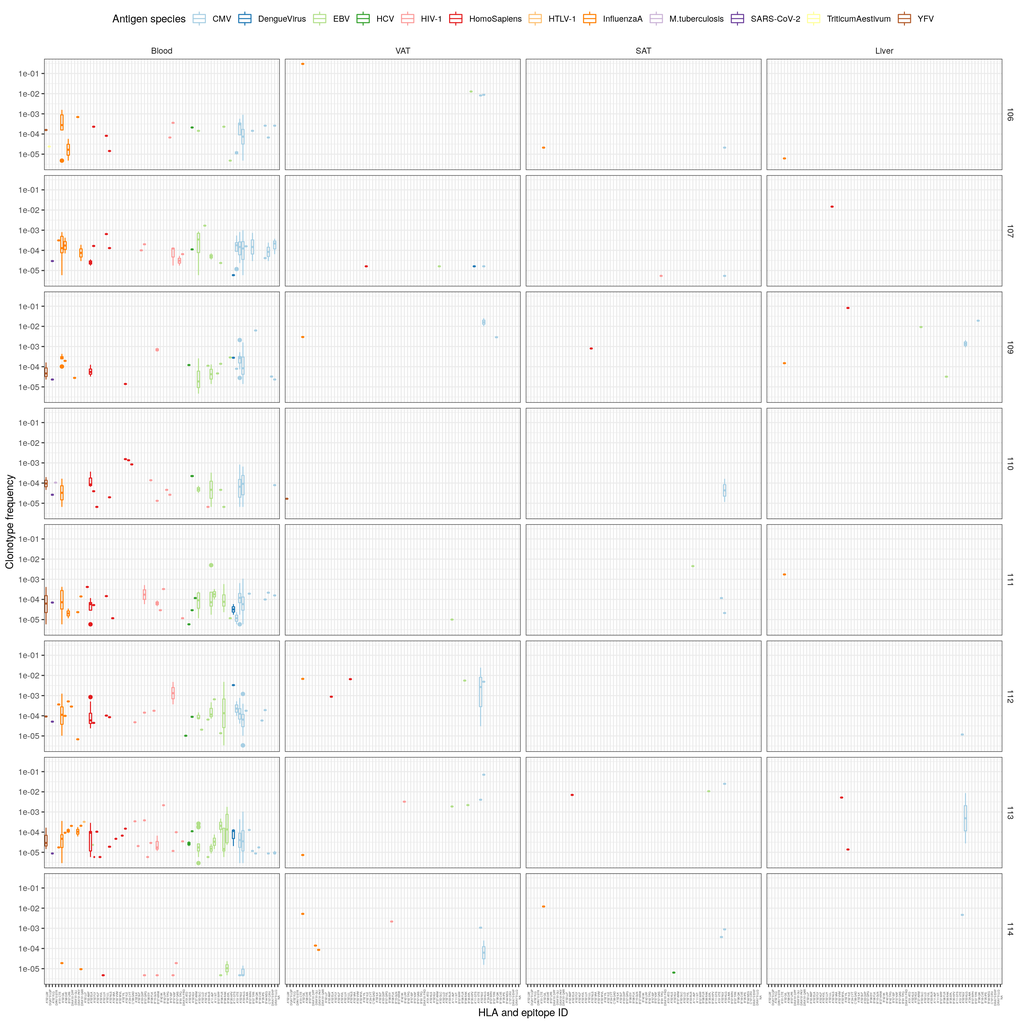

Main highlights:

- 5 out of 8 patients have large read counts of TCRs recognizing cytomegalovirus (CMV) in VAT (tissue-resident T-cells in CMV infection [have already been reported](https://www.sciencedirect.com/science/article/abs/pii/S1879625716000171))
- The same occurs for Influenza A.
- Some liver samples have high read counts of TCRs recognizing self-antigens (Species = *Homo sapiens*). It would be interesting to check which proteins are.

Exactly the same boxplot as before, but X axis are specific to each sample (in the previous plot, X axis contains every annotated epitope in any sample):

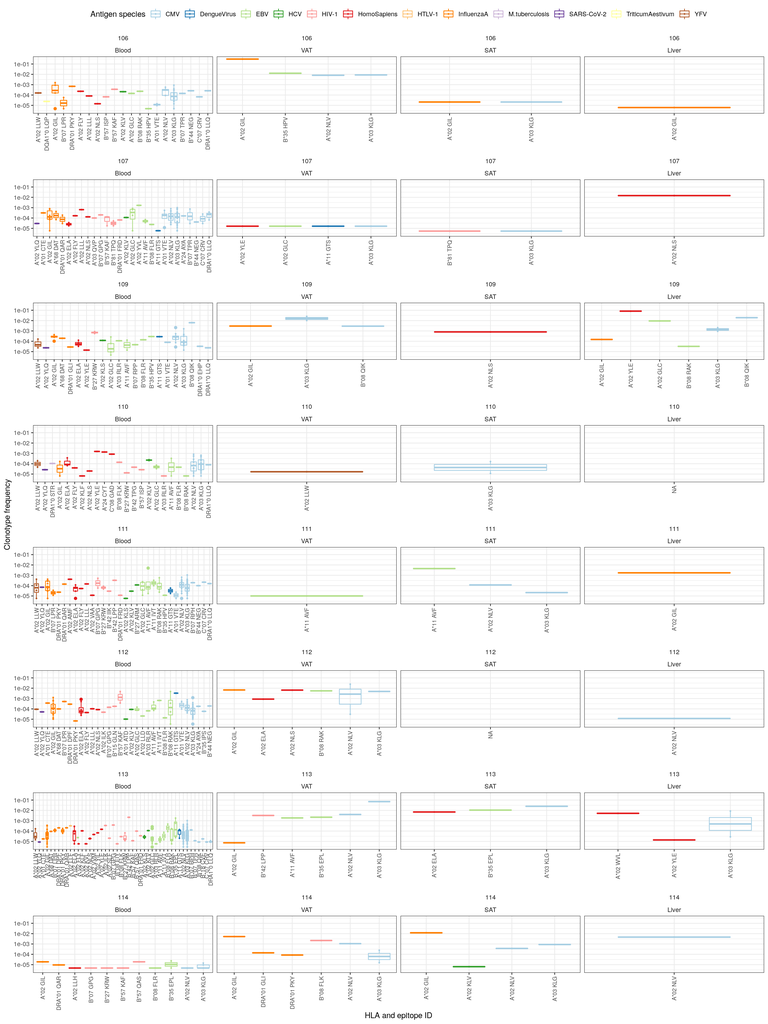

## 3.2 CMV antigen specificity in blood vs tissue

### 3.2.1 CMV proteins

- **X axis**: sample ID.
- **Y axis**: CMV protein being recognized by TCRs.
- **Circle color**: number of distinct CDR3 recognising that protein in the sample.
- **Circle size**: aggregated frequency of all CDR3 recognising that protein in the sample.

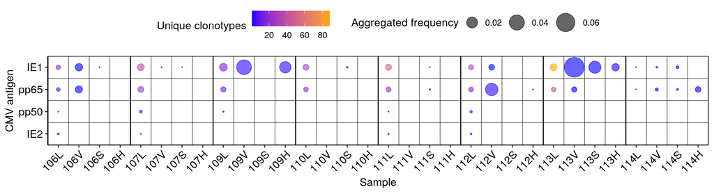

Main highlights:

- TCRs against CMV pp50 and IE2 proteins only appear in blood samples, **BUT** this could be due to a representation bias in the database, since there are few TCRs annotated against pp50 an IE2 compared to IE1 and pp65 (see the following table):

|  | CMV_antigen | TCRs_in_VDJdb |
| --- | --- | --- |
| 1 | IE1 | 12814 |
| 2 | pp65 | 5352 |
| 3 | pp50 | 202 |
| 4 | IE2 | 117 |
| 5 | UL29/28 | 10 |
| 6 | UL40 | 1 |

- Frequencies of TCRs recognising IE1 are particularly higher in some solid tissue samples, **BUT** again, this result may be biased because less T-cells in tissue = higher relative frequencies in the sample (compared with blood).

### 3.2.2 CMV epitopes

This is the same plot as before, but instead of CMV antigens, CMV epitopes are shown in the Y axis:

- **X axis**: sample ID.
- **Y axis**: CMV epitope being recognized by TCRs (identified by HLA allele, the first 3 aminoacids of the epitope and protein name)
- **Circle color**: number of distinct CDR3 recognising that epitope in the sample.
- **Circle size**: aggregated frequency of all CDR3 recognising that epitope in the sample.

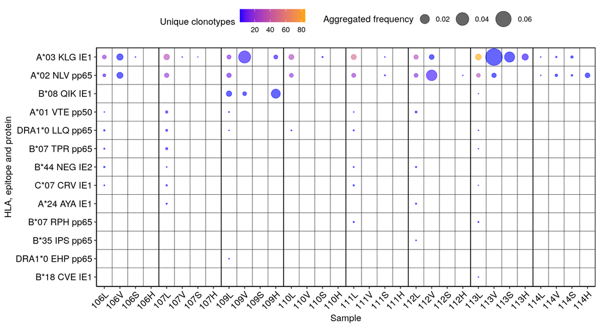

## 3.3 Self-antigens characterization

The following plot has the same structure that the previous one, but in this case, *Homo sapiens* epitopes are shown in the Y axis:

- **X axis**: sample ID.
- **Y axis**: *Homo sapiens* epitope being recognized by TCRs (identified by HLA allele, the first 3 aminoacids of the epitope and protein name)
- **Circle color**: number of distinct CDR3 recognising that epitope in the sample.
- **Circle size**: aggregated frequency of all CDR3 recognising that epitope in the sample.

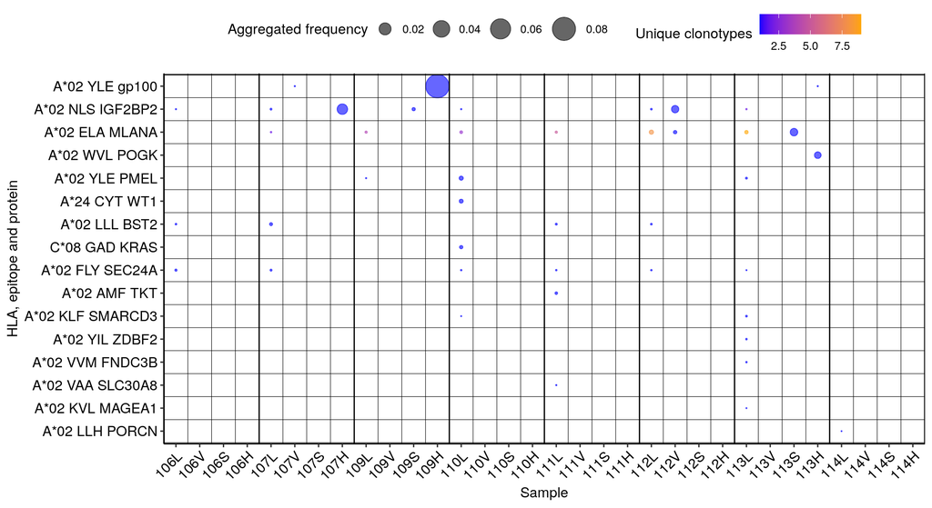

# 4 HLA typing

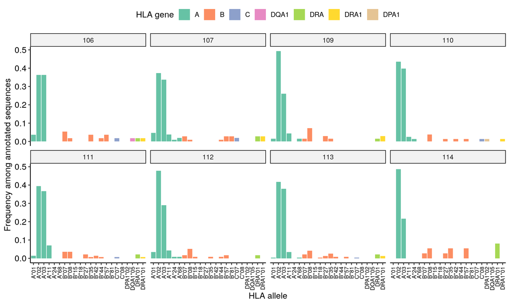